# ЕГЭ 2018 Вариант 20 EGE 2018 Variant 20

Использованы материалы:

The list of used links and books:

[ЕГЭ 2018. Математика. Профильный уровень. 20 вариантов тестов. Тематическая рабочая тетрадь.](https://drive.google.com/file/d/0B8CJrELbJAyodmtvbV8xcEtZXzA/view)

[SymPy Tutorials](http://nbviewer.jupyter.org/url/www.inp.nsk.su/~grozin/python/sympy.ipynb)

[LaTeX Mathematics](https://en.wikibooks.org/wiki/LaTeX/Mathematics)

```python
%%html
<style>
@import url('https://fonts.googleapis.com/css?family=Roboto&effect=3d|scuffed-steel|static|canvas-print|');
a, h1 h2, h3, h4, div.text_cell_render {font-family: 'Roboto'; text-shadow: 4px 4px 4px #aaa;}

h2, h3, div.output_prompt, div.output_area pre {color: slategray;}
h1, h4, div.input_prompt {color: steelblue;}
a, div.output_subarea {color: darkblue;}

span {text-shadow: 4px 4px 4px #aaa;}

body, div.output_stderr pre{background-color: aliceblue;}
div.output_stderr {background-color: slategray;}
</style>
```

```python
import numpy
import pandas
import math

import matplotlib.pyplot as plt
import matplotlib.patches as pat
from mpl_toolkits.mplot3d import Axes3D
from mpl_toolkits.mplot3d.art3d import Poly3DCollection, Line3DCollection
import matplotlib
%matplotlib inline
```

```python
import sympy
from sympy import *
from sympy import init_printing
init_printing()
```

```python
answer_dictionary = dict()
```

## Часть 1 Part 1

[figure not shown]

### Задание 1 / Task 1

В доме, в котором живет Галя, 17 этажей и несколько подъездов. На каждом этаже находится по 3 квартиры. Галя живет в квартире №58.

В каком подъезде живет Галя?

In the house where Galya lives, there are 17 floors and several sections. On each floor, there are 3 apartments. Galya lives in apartment number 58.

In which section does Galya live?

```python
1 * 17 * 3 < 58 <= 2 * 17 * 3
```

```
True
```

В каждом подъезде находится 17 * 3 = 51 квартира: в первом - с 1 по 51, во втором с 52 по 102 и т.д.

Квартира №58 находится во втором подъезде.

In each section, there are 17 * 3 = 51 apartments: in the first one - from 1 to 51, in the second from 52 to 102, etc. Apartment № 58 is located in the second section.

### Ответ / Answer: 2

```python
answer_dictionary[1]=str(2)
```

[figure not shown]

### Задание 2 / Task 2

На рисунке жирными точками показано суточное количество осадков, выпадавших в Томске с 8 по 24 января 2005 года.

По горизонтали указываются числа месяца, по вертикали - количество осадков, выпавших в соответствующий день, в миллиметрах.

Для наглядности жирные точки на рисунке соединены линией.

Определите по рисунку, сколько дней за данный период выпадало более 2 миллиметров осадков.

In the figure, the dots show the daily amount of precipitation that fell in Tomsk from 8 to 24 January 2005.

Horizontally, the numbers of the month are indicated, vertically - the amount of precipitation falling on a corresponding day, in millimeters.

For clarity, the dots in the figure are connected by a line.

Determine by using the graph how many days in the given period there were more than 2 millimeters of precipitation.

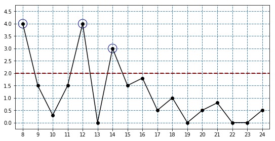

```python
f = plt.figure(figsize=(9,4.5))
ax = f.add_subplot(1,1,1)
ax.grid(c='steelblue', ls='--', lw=1)

plt.xlim(7.5,24.5)
plt.ylim(-0.25,4.75)
plt.xticks(numpy.arange(8, 25, step=1))
plt.yticks(numpy.arange(0.0, 5.0, step=0.5))

ax.plot(numpy.arange(8, 25, step=1),
        [4.0,1.5,0.3,1.5,4.0,0.0,3.0,1.5,1.8,0.5,1.0,0.0,0.5,0.8,0.0,0.0,0.5],
        '-o', c='black')
ax.axhline(2, color='darkred', ls='--', lw=2)
ax.scatter([8,12,14], [4.0,4.0,3.0], s=300, facecolor='none', color='darkblue');
```

### Ответ / Answer: 3

```python
answer_dictionary[2]=str(3)
```

[figure not shown]

### Задание 3 / Task 3

Найдите площадь треугольника, вершинами которого являются точки с координатами (1;1), (3;5), (5;3).

Find the area of the triangle with vertices at the points (1;1), (3;5), (5;3).

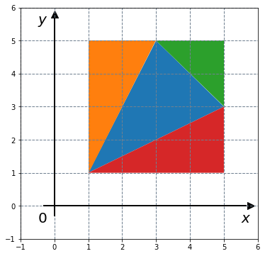

```python
plt.figure(figsize=(6,6))
plt.grid(c='slategray', ls='--', lw=1)

plt.axhline(0, 0.1, 0.95, c='black', lw=2)
plt.axvline(0, 0.1, 0.95, c='black', lw=2)

XY = [[[1,3,5], [1,5,3]],
      [[1,1,3], [1,5,5]],
      [[3,5,5], [5,5,3]],
      [[1,5,5], [1,3,1]]]
for x,y in XY:
    plt.fill(x,y)

plt.text(5.5,-0.5,r'$x$', fontsize=20)
plt.text(-0.5,5.5,r'$y$', fontsize=20)
plt.text(-0.5,-0.5,r'$0$', fontsize=20)

plt.scatter(0,5.8, marker='^', s=100, c='black')
plt.scatter(5.8,0, marker='>', s=100, c='black')

plt.xlim(-1,6)
plt.ylim(-1,6);
```

$4^2 - 2 * \frac{1}{2} * 4 * 2 - \frac{1}{2} * 2^2$

### Ответ / Answer: 6

```python
answer_dictionary[3]=str(4**2 - 4*2 - 2)
```

[figure not shown]

### Задание 4 / Task 4

На экзамене 25 билетов, Стас не выучил 5 из них.

Найдите вероятность того, что ему попадется выученный билет.

The exam materials consist of 25 variants, Stas did not study 5 of them.

Find the probability that he will get during the exam the variant he has studied.

Стас выучил 25 - 5 = 20 билетов. Вероятность того, что Стасу попадется именно такой, равна 20/25 = 0.8.

Stas has studied the materials of 25 - 5 = 20 exam variants. The probability that Stas will get exactly this during the exam is 20/25 = 0.8.

### Ответ / Answer: 0.8

```python
answer_dictionary[4]=str((25-5)/25)
```

[figure not shown]

### Задание 5 / Task 5

Найдите корень уравнения:

Find the root of the equation:

$\large{\sqrt{\frac{10}{2 * x - 8}} = \frac{1}{5}}$

Область допустимых значений / Admissible values:

$2 * x - 8 \neq 0 \iff x \neq 4$

$\large{\sqrt{\frac{10}{2 * x - 8}} = \frac{1}{5}} \iff \large{\frac{10}{2 * x - 8} = \frac{1}{25}} \iff$ $2 * x - 8 = 250 \iff x = 129$

### Ответ / Answer: 129

```python
answer_dictionary[5]=str(int((25*10 + 8) / 2))
```

[figure not shown]

### Задание 6 / Task 6

Пусть $x$ - величина одного из двух равных острых углов параллелограмма, $(180^o - x)$ - величина одного из двух равных тупых углов.

$2 * x + 180^o - x = 197^o$

$x = 197^o - 180^o = 17^o$

### Ответ / Answer: 17

```python
answer_dictionary[6]=str(197-180)
```

[figure not shown]

### Задание 7 / Task 7

На рисунке изображен график функции $\ y = f(x)$ и девять точек на оси абсцисс: $x_1,x_2,x_3,x_4,x_5,x_6,x_7,x_8,x_9$.

В скольких из этих точек производная $\ f'(x)$ функции $\ f(x)$ отрицательна?

The figure shows the graph of the function $\ y = f (x)$ and nine points on the abscissa: $x_1,x_2,x_3,x_4,x_5,x_6,x_7,x_8,x_9$.

In how many of these points is the derivative $\ f'(x)$ of the function $\ f(x)$ negative?

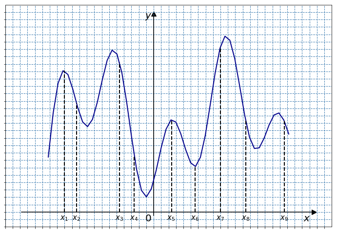

```python
f = plt.figure(figsize=(12,9))
ax = f.add_subplot(1, 1, 1, aspect=1)
ax.grid(c='steelblue', ls='--', lw=1)
ax.axhline(0, 0.05, 0.95, c='black')
ax.axvline(-1, 0.05, 0.95, c='black')

def f(x,a=6,b=0.5,c=1.2,d=1.3,e=6):
    exp = (math.pow(x, 2) + math.pow(x, 5)) * (-0.1)**5
    return a * math.exp(exp) * math.cos(b*x+d) * math.sin(c*x)+e

x = numpy.linspace(-8.1,8.1)
y = [f(el) for el in x]
ax.plot(x, y, c='darkblue', lw=2)

vl = [-7,-6.2,-3.3,-2.3,0.2,1.8,3.5,5.2,7.8]
for v in vl:
    ax.plot([v,v], [0,f(v)], lw=2, ls='--', c='black')

v = numpy.array([vl, [0.2,0.2,0.2,0.2,0.2,0.2,0.2,0.2,0.2],
                 [r'$x_1$',r'$x_2$',r'$x_3$',r'$x_4$',r'$x_5$',
                  r'$x_6$',r'$x_7$',r'$x_8$',r'$x_9$']])
for i in range(9):
    plt.text(float(v[0][i])-0.3,float(v[1][i])-0.7,v[2][i],fontsize=15)

plt.text(9.1,-0.6,r'$x$', fontsize=20)
plt.text(-1.6,13.1,r'$y$', fontsize=20)
ax.scatter(-1,13.4, marker='^', s=100, c='black')
ax.scatter(9.8,0, marker='>', s=100, c='black')
plt.text(-1.6,-0.6,r'$0$', fontsize=20)

plt.xlim(-11,11)
plt.ylim(-1,14)
plt.xticks(numpy.arange(-11,11, step=0.5), visible=False)
plt.yticks(numpy.arange(-1,14, step=0.5), visible=False);
```

Производная отрицательна на тех интервалах, где функция убывает.

The derivative is negative on those intervals where the function decreases.

$x_2,x_3,x_4,x_8,x_9$

### Ответ / Answer: 5

```python
answer_dictionary[7]=str(5)
```

[figure not shown]

### Задание 8 / Task 8

В цилиндрический сосуд налили $2100 \ см^3$ воды. Уровень жидкости оказался равным 20 см.

В воду полностью погрузили деталь. При этом уровень жидкости в сосуде поднялся на 5 см.

Чему равен объем детали? Ответ выразите в $см^3$.

$2100 \ cm^3$ of water were poured into a cylindrical vessel. The liquid level was equal to 20 cm.

The part component was completely immersed in the water. At the same time, the liquid level in the vessel rose by 5 cm.

What is the volume of a part? The answer should be expressed in $cm^3$.

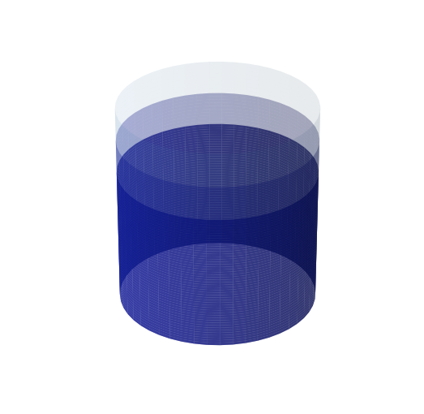

```python
f = plt.figure(figsize=(9,9))
ax = f.add_subplot(111, projection='3d')

def create_cylinder(center_x,center_y,radius,height):
    z = numpy.linspace(0, height, 50)
    theta = numpy.linspace(0, 2*numpy.pi, 50)
    theta_grid, z_grid = numpy.meshgrid(theta, z)
    x_grid = radius * numpy.cos(theta_grid) + center_x
    y_grid = radius * numpy.sin(theta_grid) + center_y
    return x_grid,y_grid,z_grid

Xc,Yc,Zc = create_cylinder(0,0,0.1,0.2)
ax.plot_surface(Xc, Yc, Zc, alpha=0.7, color='darkblue')

Xc2,Yc2,Zc2 = create_cylinder(0,0,0.1,0.25)
ax.plot_surface(Xc2, Yc2, Zc2, alpha=0.3, color='darkblue')

Xc3,Yc3,Zc3 = create_cylinder(0,0,0.1,0.3)
ax.plot_surface(Xc3, Yc3, Zc3, alpha=0.1, color='steelblue')

plt.axis('off');
```

$V_1 = \pi ∗ r^2 ∗ h_1 \implies \pi ∗ r^2 = V_1 / h_1$

$V_2 = \pi ∗ r^2 ∗ h_2 = V_1 / h_1 * h_2$

$V_2 = 2100 / 20 * 5 = 525$

### Ответ / Answer: 525

```python
answer_dictionary[8]=str(int(2100/20*5))
```

[figure not shown]

### Задание 9 / Task 9

Найдите значение выражения

Find the value of the expression

$\large{\frac{log_5{49}}{log_5{7}}}$

$\large{\frac{log_5{49}}{log_5{7}} = \frac{log_5{7^2}}{log_5{7}} = \frac{2 * log_5{7}}{log_5{7}}} = 2$

### Ответ / Answer: 2

```python
answer_dictionary[9]=str(2)
```

[figure not shown]

### Задание 10 / Task 10

Мотоциклист, движущийся по городу со скоростью $v_0 = 65 \ км/ч$, выезжает из него и сразу после выезда начинает разгоняться с постоянным ускорением $a = 20 \ км/ч^2$.

Расстояние от мотоциклиста до города, измеряемое в километрах, определяется выражением $S = v_0 * t + \large{\frac{a * t^2}{2}}$.

Определите наибольшее время, в течение которого мотоциклист будет находиться в зоне функционирования сотовой связи, если оператор гарантирует покрытие на расстоянии не далее чем в 35 км от города. Ответ выразите в минутах.

The motorcyclist moves trough the city with a speed of $v_0 = 65 \ km / h$, leaves it and immediately begins to move with a constant acceleration $a = 20 \ km / h^2$.

The distance from the motorcyclist to the city, measured in kilometers, is determined by the expression $S = v_0 * t + \large{\frac{a * t^2}{2}}$.

Determine the maximum time during which the motorcyclist will be in the area of cellular communication, if the operator guarantees coverage at a distance no further than 35 km from the city. The answer should be expressed in minutes.

$35 = 65 * t + \large{\frac{20 * t^2}{2}}$

$2 * t^2 + 13 * t - 7 = 0$

$D = 169 - 4 * 2 * (-7) = 225$

$t = (-13 + 15) / 2 * 2 = 0.5$

0.5 часа = 30 минут

0.5 hour = 30 minutes

### Ответ / Answer: 30

```python
answer_dictionary[10]=str(int(((169 + 4 * 2 * 7)**0.5 - 13) / 4 * 60))
```

[figure not shown]

### Задание 11 / Task 11

Игорь и Паша красят забор за 40 часов. Паша и Володя красят этот же забор за 48 часов, а Володя и Игорь - за 60 часов.

За сколько часов мальчики покрасят забор, работая втроем?

Igor and Pasha paint the fence in 40 hours. Pasha and Volodya paint the same fence in 48 hours, Volodya and Igor - in 60 hours.

For how many hours will the boys paint the fence, working as a threesome?

Пусть I, P, V - производительность труда Игоря, Паши и Володи соответственно.

Примем за 1 работу по окрашиванию забора.

Let I, P, V be the labor productivity of Igor, Pasha, and Volodya, respectively.

Let's evaluate as 1 the work of painting the fence.

$\begin {cases} I + P = \large{\frac{1}{40}} \ (1) \\ P + V = \large{\frac{1}{48}} \ (2) \\ V + I = \large{\frac{1}{60}} \ (3) \end {cases}$

(1) + (2) + (3):

$I + P + P + V + V + I = \large{\frac{1}{40} + \frac{1}{48} + \frac{1}{60}}$

$2 * (P + V + I) = \large{\frac{6 + 5 + 4}{240}}$

$P + V + I = \large{\frac{1}{32}}$

Время выполнения работы определяется как отношение объема работ к производительности труда.

The time of work is defined as the ratio of the volume of work to the productivity of labor.

$\large{\frac{1}{\frac{1}{32}}}$$ = 32$

### Ответ / Answer: 32

```python
answer_dictionary[11]=str(32)
```

[figure not shown]

### Задание 12 / Task 12

Найдите наименьшее значение функции

Find the minimum value of the function

$y = -12 - 8.5 * \sqrt{3} * \pi + 51 * \sqrt{3} * x - 102 * sin \ x$

на отрезке

belong to the interval

$[0; \large{\frac{\pi}{2}]}$.

```python
x = Symbol('x')
y = -12 - 8.5 * sqrt(3) * pi + 51 * sqrt(3) * x - 102 * sin(x)
```

```python
y
```

$$51 \sqrt{3} x - 102 \sin{\left (x \right )} - 8.5 \sqrt{3} \pi - 12$$

```python
# производная | the first derivative
diff(y,x)
```

$$- 102 \cos{\left (x \right )} + 51 \sqrt{3}$$

```python
# производная равна нулю: ∣ the first derivative is 0
solve(diff(y,x),x)
```

$$\left [ \frac{\pi}{6}, \quad \frac{11 \pi}{6}\right ]$$

```python
# вторая производная | the second derivative
diff(diff(y,x),x)
```

$$102 \sin{\left (x \right )}$$

```python
# y''(π/6) > 0 => min
diff(diff(y,x),x).subs({x:pi/6})
```

$$51$$

```python
# y(π/6)
y.subs({x:pi/6})
```

$$-63$$

```python
# y(0)
y.subs({x:0})
```

$$- 8.5 \sqrt{3} \pi - 12$$

```python
N(y.subs({x:0}))
```

$$-58.2518837879726$$

```python
# y(π/2)
y.subs({x:pi/2})
```

$$-114 + 17.0 \sqrt{3} \pi$$

```python
N(y.subs({x:pi/2}))
```

$$-21.4962324240549$$

### Ответ / Answer: -63

```python
answer_dictionary[12]=str(y.subs({x:pi/6}))
```

## Часть 2 Part 2

[figure not shown]

### Задание 13 / Task 13

a) Найдите корень уравнения:

a) Find the root of the equation:

$tg^2x - \large{\frac{5}{cos \ x}}$ $ + 7 = 0$.

б) Найдите все корни этого уравнения, принадлежащие промежутку

b) Find all the roots of this equation that belong to the interval

$[-\large{\frac{\pi}{2}}$;$\ \pi]$.

$tg^2x - \large{\frac{5}{cos \ x}}$ $ + 7 = 0$

1) Область допустимых значений / Admissible values:

$cos \ x \neq 0 \iff x \neq \frac{\pi}{2} + \pi * n, n \in \mathbb{N}$

2)

$\large{\frac{sin^2 x}{cos^2 x} - \frac{5}{cos \ x}}$ $ + 7 = 0$

$\large{\frac{1 - cos^2 x}{cos^2 x} - \frac{5 * cos \ x}{cos^2x} + \frac{7 * cos^2x}{cos^2x}} = 0$

$6 * cos^2 x - 5 * cos \ x + 1 = 0$

$D = 5^2 - 4 * 6 * 1 = 1$

$cos \ x = \frac{5 \pm 1}{2 * 6}$

$cos \ x = \frac{1}{3} \lor cos \ x = \frac{1}{2}$

$x = \pm \frac{\pi}{3} + 2 *\pi * k, \ x = \pm arccos\frac{1}{3} + 2 *\pi * m; k,m \in \mathbb{N}$

### Ответ / Answer: a) $\pm \frac{\pi}{3} + 2 *\pi * k, \ \pm arccos\frac{1}{3} + 2 *\pi * m; k,m \in \mathbb{N}$; б) $\pm arccos\frac{1}{3}, \pm \frac{\pi}{3}$.

```python
x = Symbol('x')
g = tan(x) ** 2 - 5 / cos(x) + 7
```

```python
g
```

$$\tan^{2}{\left (x \right )} + 7 - \frac{5}{\cos{\left (x \right )}}$$

```python
g.subs({x:-acos(1/3)}), g.subs({x:-pi/3}), g.subs({x:pi/3}), g.subs({x:acos(1/3)})
```

$$\left ( 0, \quad 0, \quad 0, \quad 0\right )$$

```python
 N(-pi/2), N(-acos(1/3)), N(-pi/3), N(pi/3), N(acos(1/3)), N(pi)
```

$$\left ( -1.5707963267949, \quad -1.23095941734077, \quad -1.0471975511966, \quad 1.0471975511966, \quad 1.23095941734077, \quad 3.14159265358979\right )$$

```python
answer_dictionary[13]='a)±π/3+2∗π∗k,±arccos(1/3)+2∗π∗m;k,m∈ℕ; б)±arccos(1/3),±π/3'
```

[figure not shown]

### Задание 14 / Task 14

Основание прямой четырёхугольной призмы $ABCDA_1B_1C_1D_1$ - прямоугольник $ABCD$, в котором $AB = 12$, $AD = \sqrt{31}$.

Расстояние между прямыми $AC$ и $B_1D_1$ равно 5.

а) Постройте прямую пересечения плоскости $BB_1D_1D$ с плоскостью, проходящей через точку $D$ перпендикулярно прямой $BD_1$.

б) Найдите косинус угла между плоскостью, проходящей через точку $D$ перпендикулярно прямой $BD_1$, и плоскостью основания призмы.

The base of the straight quadrangular prism $ABCDA_1B_1C_1D_1$ is the rectangle $ABCD$, in which $AB = 12$, $AD = \sqrt {31}$.

The distance between the lines $AC$ and $B_1D_1$ is equal to 5.

a) Construct the line of intersection of the plane $BB_1D_1D$ with the plane passing through the point $D$ perpendicular to the line $BD_1$.

b) Find the cosine of the angle between the plane passing through the point $D$ perpendicular to the line $BD_1$ and the plane of the base of the prism.

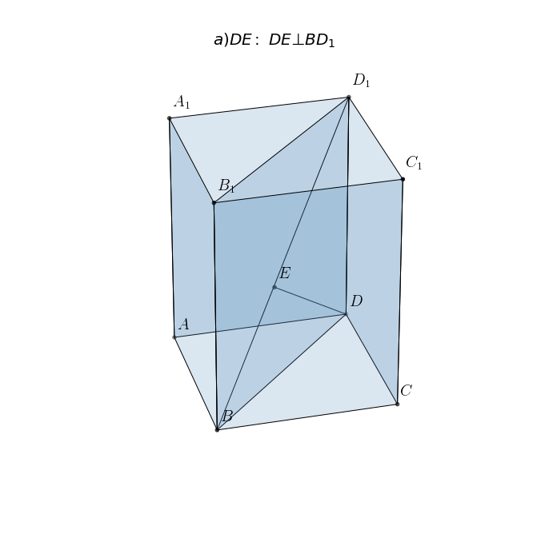

```python
f = plt.figure(figsize=(12,12))
ax = f.add_subplot(111, projection='3d')

matplotlib.rcParams['text.usetex'] = True
matplotlib.rcParams['text.latex.unicode'] = True

v = numpy.array([[5,10,0], [10,5,0], [0,5,0], [5,0,0],
                 [5,10,5], [10,5,5], [0,5,5], [5,0,5],
                 [5,4.3,2.1]])
ax.scatter3D(v[:, 0], v[:, 1], v[:, 2], color='black')

letters = [r'$D$', r'$C$',r'$A$',r'$B$',
           r'$D_1$',r'$C_1$',r'$A_1$',r'$B_1$',r'$E$']
verts = [ [v[0],v[4],v[5],v[1]],
          [v[5],v[7],v[3],v[1]],
          [v[6],v[7],v[3],v[2]],
          [v[6],v[4],v[0],v[2]],
          [v[0],v[4],v[7],v[3]],
          [v[3],v[4]],[v[0],v[8]]]

for i in range(9):
    ax.text(v[i][0]+0.1,v[i][1]+0.1,v[i][2]+0.2,
            letters[i],fontsize=20)

lines = Poly3DCollection(verts, lw=1, alpha=0.2,
                         edgecolors='black', facecolor='none')
lines.set_facecolor('steelblue')

ax.add_collection3d(lines)
plt.title(r'$a) DE: \ DE \bot BD_1$',fontsize=20)
plt.axis('off');
```

б)

1) $DD_1 \bot BD, DE \bot BD_1, \angle DBD_1 = \angle DBE \implies \angle BDE = \angle BD_1D$.

2) По теореме Пифагора найдем диагональ основания призмы:

2) By the Pythagorean theorem, we find the diagonal of the base of the prism:

$\triangle ABD: BD = \sqrt{AB^2 + AD^2} = \sqrt{12^2 + 31} = 5\sqrt{7}$.

3) Расстояние между прямыми $AC$ и $B_1D_1$ равно расстоянию между основаниями, то есть высоте призмы: $DD_1 = 5$.

3) The distance between the lines $AC$ and $B_1D_1$ is equal to the distance between the bases, that is, the height of the prism: $DD_1 = 5$.

$\triangle BDD_1: BD_1 = \sqrt{BD^2 + DD_1^2} = \sqrt{175 + 25} = 10\sqrt{2}$

4) $cos\angle BDE = cos\angle BD_1D = \large{\frac{DD_1}{BD_1} = \frac{5}{10\sqrt{2}} = \frac{\sqrt{2}}{4}}$

### Ответ / Answer: $\frac{\sqrt{2}}{4}$

```python
answer_dictionary[14]='√2/4'
```

[figure not shown]

### Задание 15 / Task 15

Решите неравенство:

Solve the inequality:

$9^{x-3} - 9^{x-2} + 9^{x-1} > 511$

$9^{x-3} - 9^{x-2} + 9^{x-1} > 511 \; \| * 9^3$

$9^x - 9 * 9^x + 81 * 9^x > 511 * 9^3$

$9^x * (1 - 9 + 81) > 511 * 9^3$

$9^x > 9^3 * 511 / 73$

$9^x > 9^3 * 9^{log_9{7}}$

$9^x > 9^{3 + log_9{7}}$

$x > 3 + log_9{7}$

### Ответ / Answer: $(3 + log_9{7};+\infty)$

```python
answer_dictionary[15]='(3+log_9{7};+∞)'
```

```python
# check the decision method
x = Symbol('x')
```

```python
solve(9**(x-3) - 9**(x-2) + 9**(x-1) > 511)
```

$$x < \infty \wedge \frac{\log{\left (5103 \right )}}{\log{\left (9 \right )}} < x$$

[figure not shown]

### Задание 16 / Task 16

Основания BC и AD трапеции ABCD равны 3 и 7. На боковых сторонах AB и CD отмечены точки E и F так, что прямая EF, параллельная основаниям, разбивает трапецию на две трапеции, площади которых относятся как 2:3. Прямые AB и CD пересекаются в точке M.

а) Докажите, что треугольники AMB, BMC и EMF подобны.

б) Найдите длину отрезка EF.

The bases BC and AD of the trapezoid ABCD are 3 and 7. On the sides AB and CD the points E and F are marked so that the straight line EF is parallel to the bases and divides the trapezium into two trapezoids whose areas are at the proportion 2:3. The lines AB and CD intersect at the point M.

a) Prove that the triangles AMB, BMC and EMF are similar.

b) Find the length of the segment EF.

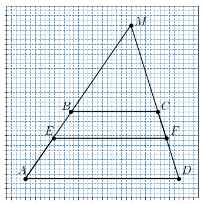

```python
f = plt.figure(figsize=(6,6))
ax = f.add_subplot(1, 1, 1, aspect=1)
ax.grid(c='steelblue', ls='--', lw=1)

ax.plot([-8,8,3,-8,-5.1,6.7,5.8,-3.3],
        [-8,-8,8,-8,-3.8,-3.8,-1,-1],
        '-o', c='black')

v = numpy.array([[-8.8,8.3,-6.0,7.1,-4.2,6.2,3.4],
                 [-7.5,-7.5,-3.4,-3.4,-0.8,-0.8,8],
                 [r'$A$',r'$D$',r'$E$',r'$F$',r'$B$',r'$C$',r'$M$']])

for i in range(7):
    plt.text(float(v[0][i]),float(v[1][i]),v[2][i],fontsize=20)

plt.xlim(-10,10)
plt.ylim(-10,10)
plt.xticks(numpy.arange(-10, 10, step=0.5), visible=False)
plt.yticks(numpy.arange(-10, 10, step=0.5), visible=False);
```

1)

$S_{EBCF} = S_{\triangle MEF} - S_{\triangle MBC}$; $S_{AEFD} = S_{\triangle MAD} - S_{\triangle MEF}$

$S_{EBCF} : S_{AEFD} = 2 : 3 \implies 3 * (S_{\triangle MEF} - S_{\triangle MBC}) = 2 * (S_{\triangle MAD} - S_{\triangle MEF})$

$S_{\triangle MEF} = (2 * S_{\triangle MAD} + 3 * S_{\triangle MBC}) / 5$

$AD \ \| \ EF \ \| \ BC \implies \triangle MEF \sim \triangle MAD \sim \triangle MBC$

$BC : AD = 3 : 7 \implies S_{\triangle MBC} : S_{\triangle MAD} = 9 : 49 \implies S_{\triangle MAD} = 49 * S_{\triangle MBC} / 9$

$S_{\triangle MEF} = (2 * 49 * S_{\triangle MBC} / 9 + 3 * S_{\triangle MBC}) / 5$

$\large{\frac{S_{\triangle MEF}}{S_{\triangle MBC}}} = \frac{98 + 27}{45} = \frac{25}{9}$

$\large{\frac{EF}{BC} = \sqrt{\frac{25}{9}}} = \frac{5}{3} \implies $$EF = BC * 5 / 3 = 3 * 5 / 3 = 5$

2)

$S_{EBCF} : S_{AEFD} = 3 : 2 \implies S_{\triangle MEF} = (3 * S_{\triangle MAD} + 2 * S_{\triangle MBC}) / 5$

$S_{\triangle MEF} = (3 * 49 * S_{\triangle MBC} / 9 + 2 * S_{\triangle MBC}) / 5$

$\large{\frac{S_{\triangle MEF}}{S_{\triangle MBC}}} = \frac{147 + 18}{45} = \frac{33}{9}$

$\large{\frac{EF}{BC} = \sqrt{\frac{33}{9}}} = \frac{\sqrt{33}}{3} \implies $$EF = BC * \sqrt{33} / 3 = 3 * \sqrt{33}/ 3 = \sqrt{33}$

### Ответ / Answer: $5 \lor \sqrt{33}$

```python
answer_dictionary[16]='5∨√33'
```

[figure not shown]

### Задание 17 / Task 17

31 декабря 2014 года Родион взял в банке некоторую сумму в кредит под некоторый процент годовых.

Схема выплаты кредита следующая - 31 декабря каждого следующего года банк начисляет проценты на оставшуюся сумму долга (то есть увеличивает долг на a%), затем Родион переводит очередной транш.

Если он будет платить каждый год по `1 464 100` рублей, то выплатит долг за 4 года. Если по `2 674 100` рублей, то за 2 года.

Под какой процент Родион взял деньги в банке?

December 31, 2014, Rodion took in the bank some loan amount at a certain percentage of the annual.

The loan repayment scheme is the following - on December 31 of each following year the bank accrues the interest on the remaining amount of debt (that is, increases the debt by a%), then Rodion transfers the next tranche.

If he will pay each year for `1 464 100` rubles, then he will pay the debt for 4 years. If the `2 674 100` rubles, then for 2 years.

Under what percentage did Rodion take the money in the bank?

Пусть x - размер кредита, k - процент кредита (в долях: например, 30% процентов - 0.3 часть кредита).

Let x be the amount of the loan, k - the loan interest (in fractions: for example, 30% of interest - 0.3 part of the loan).

1) Рассмотрим выплату в течение двух лет.

1) Let's consider the payment within two years.

После первого начисления процентов и выплаты первого транша `2674100` руб. сумма долга составит:

After the first accrual of the interest and the first tranche of `2674100` rub. the amount of debt will be:

$x * (1 + k) - 2674100$

После второго начисления процентов останется выплатить такую же сумму:

After the second accrual of the interest will remain to pay the same amount:

$(x * (1 + k) - 2674100) * (1 + k) = 2674100$.

$x + k * x - 2674100 + k * x + k^2 * x - 2674100 * k = 2674100$

$x * (1 + 2k + k^2) = 2674100 * k + 5348200$

$x = \large{\frac{2674100 * (k + 2)}{(k + 1)^2}}$

2) Рассмотрим выплату в течение четырех лет.

2) Let's consider the payment within four years.

После первого начисления процентов и выплаты первого транша `1464100` руб. сумма долга составит:

After the first accrual of the interest and the first tranche of `1464100` rub. the amount of debt will be:

$x * (1 + k) - 1464100$.

После второго, третьего и четвертого начисления процентов и второго и третьего транша останется выплатить такую же сумму:

After the same procedure for the next years:

$(((x * (1 + k) - 1464100) * (1 + k) - 1464100) * (1 + k) - 1464100) * (1 + k) = 1464100$.

$((k^2 * x + 2 * k * x − 1464100 * k + x − 2928200) * (1 + k) - 1464100) * (1 + k) = 1464100$.

$(k^3 * x + 3 * k^2 * x − 1464100 * k^2 + 3 * k * x − 4392300 * k + x − 4392300) * (1 + k) = 1464100$.

$k^4 * x + 4 * k^3 * x − 1464100 * k^3 + 6 * k^2 * x − 5856400 * k^2 + 4 * k * x − 8784600 * k + x − 4392300 = 1464100$.

$ k^4 * x + 4 * k ^3 * x + 6 * k^2 * x + 4 * k * x + x = 1464100 * (k^3 + 4 * k^2 + 6 * k + 4)$

$x = \large{\frac{1464100 * (k^3 + 4 * k^2 + 6 * k + 4)}{(k + 1)^4}}$

3) Из 1) и 2):

3) From 1) and 2):

$\large{\frac{2674100 * (k + 2)}{(k + 1)^2} = \frac{1464100 * (k^3 + 4 * k^2 + 6 * k + 4)}{(k + 1)^4}}$

$26741 * (k + 2) * (k + 1)^2 = 14641 * (k^3 + 4 * k^2 + 6 * k + 4)$

$26741 * (k + 2) * (k + 1)^2 = 14641 * (k * (k^2 + 4 * k + 4) + 2 * (k + 2))$

$26741 * (k + 2) * (k + 1)^2 = 14641 * (k + 2) * (k^2 + 2 * k + 2)$

$26741 * (k^2 + 2 * k + 1) = 14641 * (k^2 + 2 * k + 2)$

$12100 * k^2 + 24200 * k - 2541 = 0$

$100 * k^2 + 200 * k - 21 = 0$

$D = 40000 - 4 * (-21) * 100 = 48400$

$k = \large{\frac{-200 + \sqrt{48400}}{2 * 100}} = 0.1$

Долю 0.1 от суммы кредита выразим в процентах: 10%.

The proportion 0.1 of the loan amount is expressed as a percentage: 10%.

### Ответ / Answer: 10

```python
# check the decision method
x = Symbol('x')
k = Symbol('k')
```

```python
p1 = (x * (1 + k) - 2674100) * (1 + k) - 2674100
```

```python
expand(p1)
```

$$k^{2} x + 2 k x - 2674100 k + x - 5348200$$

```python
p2 = (((x * (1 + k) - 1464100) * (1 + k) - 1464100) * (1 + k) - 1464100) * (1 + k) - 1464100
```

```python
solve(p1,x)
```

$$\left [ \frac{2674100 \left(k + 2\right)}{\left(k + 1\right)^{2}}\right ]$$

```python
solve(p2,x)
```

$$\left [ \frac{1464100}{\left(k + 1\right)^{4}} \left(k^{3} + 4 k^{2} + 6 k + 4\right)\right ]$$

```python
solve(solve(p1,x)[0]-solve(p2,x)[0],k)
```

$$\left [ - \frac{21}{10}, \quad -2, \quad \frac{1}{10}\right ]$$

```python
answer_dictionary[17]=str(10)
```

[figure not shown]

### Задание 18 / Task 18

Найдите все значения параметра a, при каждом из которых неравенство

Find all the values of the parameter a, for each of which the inequality

$\bigg| \large{\frac{x^2 + x - 2 * a}{x + a}}$$ - 1 \bigg| \leq 2$

не имеет решений на интервале $(1; 2)$.

has no solutions on the interval $(1; 2)$.

Преобразуем неравенство:

Let's transform the inequality:

$\bigg| \large{\frac{x^2 + x - 2 * a}{x + a}}$$ - 1 \bigg| \leq 2$ $\iff \bigg| \large{\frac{x^2 - 3 * a}{x + a}}$$ \bigg| \leq 2$

$\begin {cases} \mid x^2 - 3 * a\mid \leq 2 * \mid x + a \mid \\ x \neq -a \end {cases} \iff \begin {cases} (x^2 - 3 * a)^2 \leq 4 * (x + a)^2 \\ x \neq -a \end {cases} \iff \begin {cases} (x^2 - 3 * a)^2 - 4 * (x + a)^2 \leq 0\\ x \neq -a \end {cases} \iff$

$\begin {cases} (x^2 - 3 * a - 2 * (x + a))(x^2 - 3 * a + 2 * (x + a)) \leq 0\\ x \neq -a \end {cases} \iff \begin {cases} (x^2 - 2 * x - 5 * a) * (x^2 + 2 * x - a) \leq 0 \\ x \neq -a \end {cases}$

Решений нет в двух случаях:

There are no solutions in two cases:

1) $x^2 - 2 * x - 5 * a > 0 \land x^2 + 2 * x - a > 0 \iff a < -0.2$

Дискриминант квадратных уравнений должен быть отрицательным.

The discriminant of the quadratic equations must be negative.

$\begin {cases} D_1 = 4 + 20 * a < 0 \implies a < -0.2 \\ D_2 = 4 + 4 * a < 0 \implies a < -1 \end {cases}$

2) $x^2 - 2 * x - 5 * a < 0 \land x^2 + 2 * x - a < 0, \forall x \in (1;2)$

$a > 0.2 * x^2 - 0.4 * x \land a > x^2 + 2 * x, \forall x \in (1;2) \ (*)$

На указанном отрезке функции $f_1(x) = 0.2 * x^2 - 0.4 * x$ и $f_2(x) = x^2 + 2 * x$ возрастают.

Для выполнения $(*)$ достаточно, чтобы a было больше или равно максимальному из значений этих функций в точке x=2.

On the indicated interval, the functions $f_1(x) = 0.2 * x^2 - 0.4 * x$ and $f_2(x) = x^2 + 2 * x$ increase.

To execute $(*)$, it is sufficient that a is greater than or equal to the maximum value of these functions at the point x = 2.

$5 * a \geq 2^2 - 2 * 2 \land a \geq 2^2 + 2 * 2 \iff a \geq 8$

### Ответ / Answer: $(-\infty;-0.2], [8;+\infty)$

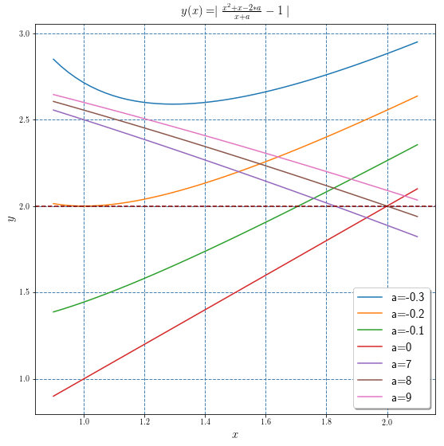

```python
def F(x,a): return abs((x ** 2 + x - 2 * a ) / (x + a) - 1)
X = numpy.linspace(0.9, 2.1)

plt.figure(figsize=(9,9))
for a in [-0.3, -0.2, -0.1, 0, 7, 8, 9]:
    plt.plot(X, [F(x,a) for x in X], label='a='+str(a))

plt.axhline(2, c='darkred', ls='--')
plt.legend(shadow=True, loc=4, fontsize=15)
plt.xlabel(r'$x$', fontsize=15)
plt.ylabel(r'$y$', fontsize=15)
plt.title(r'$y(x) = \mid \frac{x^2 + x - 2 * a}{x + a} - 1 \mid$', fontsize=15)
plt.grid(c='steelblue', ls='--', lw=1);
```

```python
# check the decision method
x = Symbol('x')
a = Symbol('a')
```

```python
n = Abs((x ** 2 + x - 2 * a) / (x + a) - 1)
```

```python
n.subs({a:-0.2})
```

$$\left|{1 - \frac{x^{2} + x + 0.4}{x - 0.2}}\right|$$

```python
solve(n.subs({a:-0.2}) <= 2)
```

$$\left(-1.89442719099992 \leq x \wedge x \leq -0.105572809000084\right) \vee x = 1.0$$

```python
# a=-0.2
solve((x ** 2 - 2 * x + 1)*(x ** 2 + 2 * x + 0.2), x)
```

$$\left [ -1.89442719099992, \quad -0.105572809000084, \quad 1.0\right ]$$

```python
n.subs({a:8})
```

$$\left|{1 - \frac{x^{2} + x - 16}{x + 8}}\right|$$

```python
solve(n.subs({a:8}) <= 2)
```

$$\left(2 \leq x \wedge x \leq 1 + \sqrt{41}\right) \vee \left(x \leq -4 \wedge - \sqrt{41} + 1 \leq x\right)$$

```python
answer_dictionary[18]='(−∞;−0.2],[8;+∞)'
```

[figure not shown]

### Задание 19 / Task 19

Найдите наибольшее натуральное число, каждая некрайняя цифра которого меньше среднего арифметического соседних с ней цифр.

Find the largest natural number, each not the first and not the last digit of which is less than the arithmetic mean of its neighboring digits.

Построим последовательность цифр по указанному в условии правилу.

Для того, чтобы число получилось максимальным, начнем с 9.

Let's construct a sequence of digits according to the rule specified in the condition.

In order to get the maximum number, let's start with 9.

- 987: 8 = (9+7)/2
- 986: 8 > (9+6)/2
- 985, 984, ...
- 976: 7 < (9+6)/2
  - 9765: 6 = (7+5)/2
  - 9764: 6 > (7+4)/2
  - 9763, 9762, ...
- 975: 7 = (9+5)/2
- 974: 7 > (9+4)/2
- 973, 972, ...
- 965: 6 < (9+5)/2
  - 9654: 5 = (6+4)/2
  - 9653: 5 > (6+3)/2
- 964: 6 < (9+4)/2
  - 9643: 4 < (6+3)/2
    - 96433: 3 < (3+4)/2
      - 964334: 3 < (3+4)/2
        - 9643346: 4 < (3+6)/2
          - 96433469: 6 < (4+9)/2
  - 9642: 4 = (6+2)/2
  - 9641: 4 > (6+1)/2
  - 9640: 4 > (6+0)/2
- 963: 6 = (9+3)/2
- 962: 6 > (9+2)/2
- 961, 960
- 954: 5 < (9+4)/2
  - 9543: 4 = (5+3)/2
  - 9542: 4 > (5+2)/2
  - 9541, 9540, ...
- 953: 5 < (9+3)/2
  - 9532: 3 < (5+2)/2
    - 95321: 2 = (3+1)/2
    - 95320: 2 > (3+0)/2
  - 9531: 3 = (5+1)/2
  - 9530: 3 > (5+0)/2
- 952: 5 < (9+2)/2
  - 9521: 2 < (5+1)/2
    - 95210: 1 = (2+0)/2
- 951: 5 = (9+1)/2
- 950: 5 > (9+0)/2
- 941: 4 < (9+1)/2
  - 9410: 1 < (4+0)/2
    - 94100: 0 < (1+0)/2
      - 941001: 0 < (0+1)/2
        - 9410014: 1 < (0+4)/2
          - 94100149: 4 < (1+9)/2
- 940: 4 < (9+0)/2
  - 9400: 0 < (4+0)/2
    - 94004: 0 < (0+4)/2
      - 940049: 4 < (0+9)/2

The largest of the constructed numbers is 96433469.

### Ответ / Answer: 96433469

```python
answer_dictionary[19]=str(96433469)
```

## Ответы / Answers

| 1 | 2 | 3 | 4 | 5 | 6 | 7 | 8 | 9 | 10 | 11 | 12 |
| --- | --- | --- | --- | --- | --- | --- | --- | --- | --- | --- | --- |
| 2 | 3 | 6 | 0.8 | 129 | 17 | 5 | 525 | 2 | 30 | 32 | -63 |

| 13 | 14 | 15 | 16 | 17 | 18 | 19 |
| --- | --- | --- | --- | --- | --- | --- |
| a) $\pm \frac{\pi}{3} + 2\pi k,$ $\pm arccos\frac{1}{3} + 2\pi m;$ $k,m \in \mathbb{N}$; б) $\pm arccos\frac{1}{3}, \pm \frac{\pi}{3}$ | $\frac{\sqrt{2}}{4}$ | $(3 + log_9{7};+\infty)$ | $5 \lor \sqrt{33}$ | $10$ | $(-\infty;-0.2], [8;+\infty)$ | $96433469$ |

[figure not shown]